# Module 62

#### Contrast SVE:

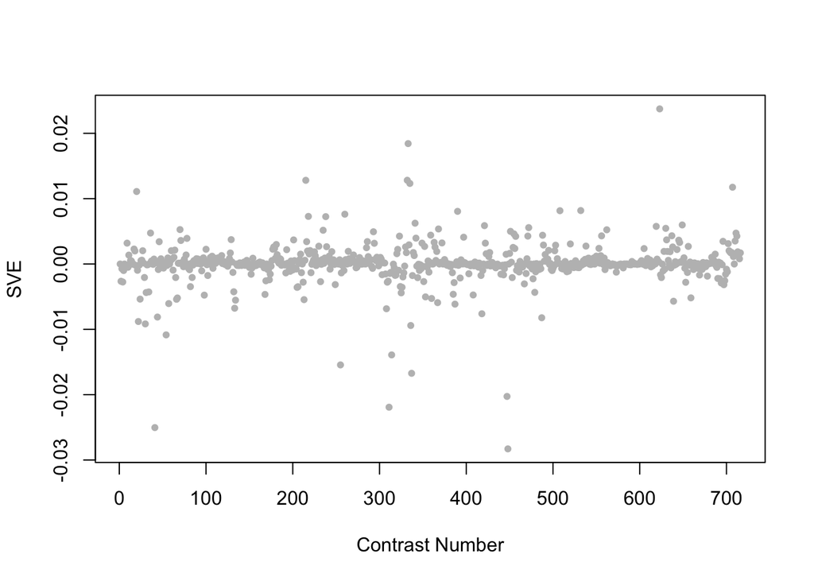

Positive SVE Contrasts:

|  | Contrast.Num | SVE | GEO.GSE | Cond.1 | Cond.2 | Mutation |
| --- | --- | --- | --- | --- | --- | --- |
| GSE20053.s1t1.vs.s0t1 | 623 | 0.02 | GSE20053 | C. elegans N2_Y. pestis KIM5_24h_Sample A | C. elegans N2_E. coli OP50_24h_Sample A |  |
| GSE38997.s3t2.vs.s1t2 | 333 | 0.02 | GSE38997 | experiment 4 UVC- and EtBr-exposed samples at 24 h 4eu24 | experiment 4 control samples at 24 h 4c24 |  |
| GSE38997.s2t2.vs.s1t2 | 332 | 0.01 | GSE38997 | experiment 4 EtBr-exposed samples at 24 h 4e24 | experiment 4 control samples at 24 h 4c24 |  |
| GSE42592A.s3t2.vs.s0t2 | 215 | 0.01 | GSE42592 | acrylamide_high_expose-4h_rep1 | acrylamide_control_expose-4h_rep1 |  |
| GSE38997.s3t2.vs.s2t2 | 335 | 0.01 | GSE38997 | experiment 4 UVC- and EtBr-exposed samples at 24 h 4eu24 | experiment 4 EtBr-exposed samples at 24 h 4e24 |  |

Negative SVE Contrasts:

|  | Contrast.Num | SVE | GEO.GSE | Cond.1 | Cond.2 | Mutation |
| --- | --- | --- | --- | --- | --- | --- |
| GSE27401.s1t1.vs.s2t1 | 448 | -0.03 | GSE27401 | Heat Killed E coli #1 | Heat Killed C. albicans #1 |  |
| GSE9665.s12t3.vs.s0t3 | 41 | -0.03 | GSE9665 | mex-3 vab-7 230 A | mex-3 230 A | vab-7 |
| GSE41056.s2t2.vs.s0t2 | 311 | -0.02 | GSE41056 | RDE_1_inf_1 | N2_inf_1 | rde-1 |
| GSE27401.s1t1.vs.s3t1 | 447 | -0.02 | GSE27401 | Heat Killed E coli #1 | C. albicans alive #1 |  |
| GSE38997.s4t2.vs.s3t2 | 337 | -0.02 | GSE38997 | experiment 4 UVC-exposed samples at 24 h 4u24 | experiment 4 UVC- and EtBr-exposed samples at 24 h 4eu24 |  |

$~$

#### Contrast SVE, Up-Regulated Genes Only:

Calculating SVE for up-regulated and down-regulated genes separately may be more informative in many cases than projecting the up- and down- gene sets together. This is due to the fact that the weight distribution of many modules is highly skewed, indicating that only one of the hemi-modules may be biologically meaningful (i.e., a set of genes are strongly correlated by only a few genes (or none) are strongly anti-correlated to that set.)

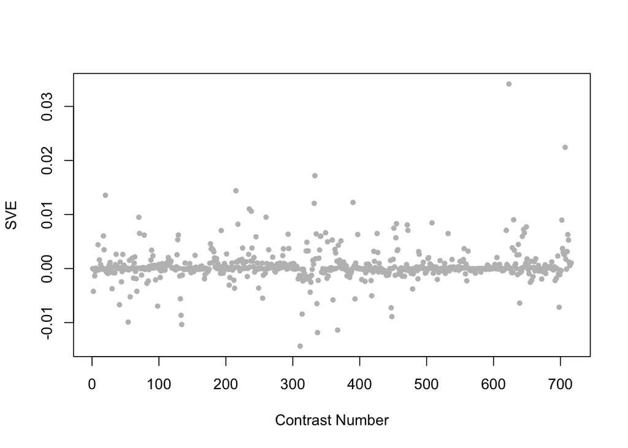

Positive SVE Contrasts:

|  | Contrast.Num | SVE | GEO.GSE | Cond.1 | Cond.2 | Mutation |
| --- | --- | --- | --- | --- | --- | --- |
| GSE20053.s1t1.vs.s0t1 | 623 | 0.03 | GSE20053 | C. elegans N2_Y. pestis KIM5_24h_Sample A | C. elegans N2_E. coli OP50_24h_Sample A |  |
| GSE11055.s1t7.vs.s1t1 | 707 | 0.02 | GSE11055 | L1-L2 larvae 15 hr after hatching in the presence of food | embryo 2 hr before hatching |  |
| GSE38997.s3t2.vs.s1t2 | 333 | 0.02 | GSE38997 | experiment 4 UVC- and EtBr-exposed samples at 24 h 4eu24 | experiment 4 control samples at 24 h 4c24 |  |
| GSE42592A.s3t2.vs.s0t2 | 215 | 0.01 | GSE42592 | acrylamide_high_expose-4h_rep1 | acrylamide_control_expose-4h_rep1 |  |
| GSE9665.s9t1.vs.s0t1 | 20 | 0.01 | GSE9665 | mex-3 scrt-1 143 A | mex-3 143 A | scrt-1 |

Negative SVE Contrasts:

|  | Contrast.Num | SVE | GEO.GSE | Cond.1 | Cond.2 | Mutation |
| --- | --- | --- | --- | --- | --- | --- |
| GSE41056.s2t2.vs.s0t2 | 311 | -0.01 | GSE41056 | RDE_1_inf_1 | N2_inf_1 | rde-1 |
| GSE38997.s4t2.vs.s3t2 | 337 | -0.01 | GSE38997 | experiment 4 UVC-exposed samples at 24 h 4u24 | experiment 4 UVC- and EtBr-exposed samples at 24 h 4eu24 |  |
| GSE35360A.s1t1.vs.s0t1 | 367 | -0.01 | GSE35360 | HF 11d_0.2_rep1 | HF 11d control_rep1 |  |
| GSE52064.s1t1.vs.s4t1 | 134 | -0.01 | GSE52064 | wildtype_1 | lin-54;mes-4_1 | lin-54;mes-4 |
| GSE9665.s9t2.vs.s9t1 | 54 | -0.01 | GSE9665 | mex-3 scrt-1 186 A | mex-3 scrt-1 143 A |  |

$~$

#### Contrast SVE, Down-Regulated Genes Only:

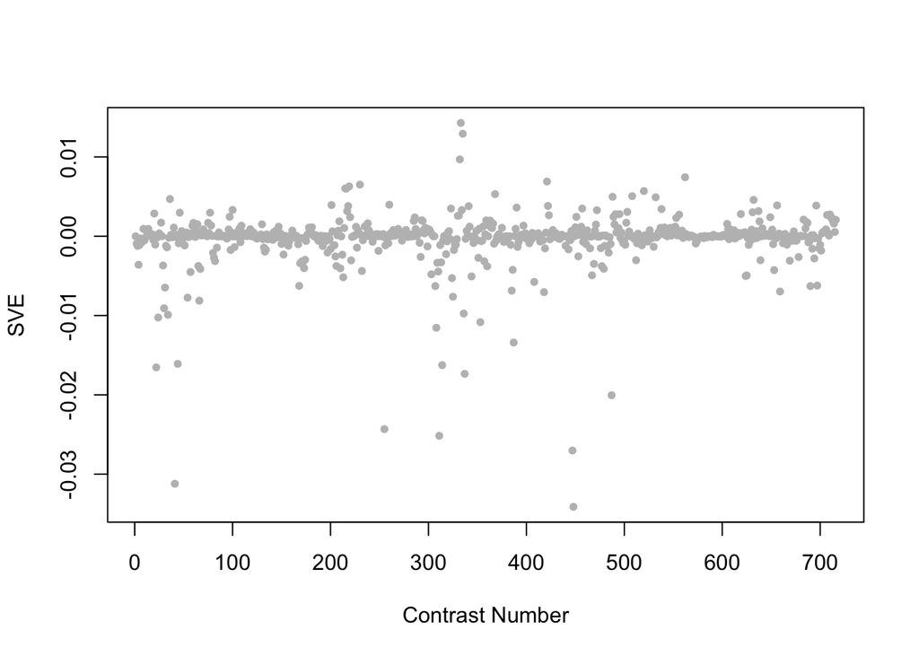

Positive SVE Contrasts:

|  | Contrast.Num | SVE | GEO.GSE | Cond.1 | Cond.2 | Mutation |
| --- | --- | --- | --- | --- | --- | --- |
| GSE38997.s3t2.vs.s1t2 | 333 | 0.01 | GSE38997 | experiment 4 UVC- and EtBr-exposed samples at 24 h 4eu24 | experiment 4 control samples at 24 h 4c24 |  |
| GSE38997.s3t2.vs.s2t2 | 335 | 0.01 | GSE38997 | experiment 4 UVC- and EtBr-exposed samples at 24 h 4eu24 | experiment 4 EtBr-exposed samples at 24 h 4e24 |  |
| GSE38997.s2t2.vs.s1t2 | 332 | 0.01 | GSE38997 | experiment 4 EtBr-exposed samples at 24 h 4e24 | experiment 4 control samples at 24 h 4c24 |  |
| GSE2180.s4t5.vs.s3t5 | 562 | 0.01 | GSE2180 | pp66-1 | p66-1 | pal-1(RNAi) |
| GSE28494.s1t2.vs.s0t2 | 421 | 0.01 | GSE28494 | lin-54(n3423) dissected germline 1 | wild-type N2 dissected germline 1 | lin-54 |

Negative SVE Contrasts:

|  | Contrast.Num | SVE | GEO.GSE | Cond.1 | Cond.2 | Mutation |
| --- | --- | --- | --- | --- | --- | --- |
| GSE27401.s1t1.vs.s2t1 | 448 | -0.03 | GSE27401 | Heat Killed E coli #1 | Heat Killed C. albicans #1 |  |
| GSE9665.s12t3.vs.s0t3 | 41 | -0.03 | GSE9665 | mex-3 vab-7 230 A | mex-3 230 A | vab-7 |
| GSE27401.s1t1.vs.s3t1 | 447 | -0.03 | GSE27401 | Heat Killed E coli #1 | C. albicans alive #1 |  |
| GSE41056.s2t2.vs.s0t2 | 311 | -0.03 | GSE41056 | RDE_1_inf_1 | N2_inf_1 | rde-1 |
| GSE41486.s2t1.vs.s1t1 | 255 | -0.02 | GSE41486 | C. elegans grown without a-SWCNT treatment for 48 hr at 22°C. | C. elegans exposed to 500 μg/mL of a-SWCNT for 48 hr at 22°C. |  |

$~$

$~$

#### GO Term Enrichment:

This analysis tests each hemi-module for enrichment of specific GO terms. Only gene-level annotations (e.g., as would be found on the gene’s page in Wormbase) are tested - the hierarchical structure of the GO ontology is not taken into account.

*Note: At least the top two most enriched terms from each GO domain (BP/MF/CC) are shown, even when not statistically significant.*

##### Enriched GO terms: Hemi-module A

| ID | GO.Term | GO Domain | Raw p-value | Adj p-value |
| --- | --- | --- | --- | --- |
| [GO_0019835](http://amigo.geneontology.org/amigo/term/GO:0019835) | cytolysis | BP | 6.44e-05 | 2.35e-01 |
| [GO_0042742](http://amigo.geneontology.org/amigo/term/GO:0042742) | defense response to bacterium | BP | 8.21e-04 | 1.00e+00 |
| [GO_0004364](http://amigo.geneontology.org/amigo/term/GO:0004364) | glutathione transferase activity | MF | 4.68e-04 | 4.87e-01 |
| [GO_0003796](http://amigo.geneontology.org/amigo/term/GO:0003796) | lysozyme activity | MF | 4.77e-04 | 4.87e-01 |
| [GO_0005811](http://amigo.geneontology.org/amigo/term/GO:0005811) | lipid droplet | CC | 1.59e-03 | 7.71e-01 |
| [GO_0031906](http://amigo.geneontology.org/amigo/term/GO:0031906) | late endosome lumen | CC | 3.32e-03 | 7.71e-01 |

##### Enriched GO terms: Hemi-module B

| ID | GO.Term | GO Domain | Raw p-value | Adj p-value |
| --- | --- | --- | --- | --- |
| [GO_0038203](http://amigo.geneontology.org/amigo/term/GO:0038203) | TORC2 signaling | BP | 2.24e-03 | 1.00e+00 |
| [GO_0006513](http://amigo.geneontology.org/amigo/term/GO:0006513) | protein monoubiquitination | BP | 4.48e-03 | 1.00e+00 |
| [GO_0042500](http://amigo.geneontology.org/amigo/term/GO:0042500) | aspartic endopeptidase activity, intramembrane cleaving | MF | 4.48e-03 | 1.00e+00 |
| [GO_0005366](http://amigo.geneontology.org/amigo/term/GO:0005366) | myo-inositol:proton symporter activity | MF | 6.72e-03 | 1.00e+00 |
| [GO_0005615](http://amigo.geneontology.org/amigo/term/GO:0005615) | extracellular space | CC | 2.94e-03 | 1.00e+00 |
| [GO_0071458](http://amigo.geneontology.org/amigo/term/GO:0071458) | integral component of cytoplasmic side of endoplasmic reticulum membrane | CC | 4.48e-03 | 1.00e+00 |

$~$

$~$

#### Tissue Enrichment:

This analysis tests each hemi-module for enrichment of genes associated with anatomy terms. Negative enrichment scores indicate fewer hemi-module genes than expected by random chance were associated with the anatomy term in question.

##### Enriched tissues: Hemi-module A

No significant annotations.

##### Enriched tissues: Hemi-module B

No significant annotations.

$~$

$~$

#### HOMER promoter motif enrichment:

This analysis tests each hemi-module for enrichment of 108 known *C. elegans* transcription factor binding site motifs (see [108 CE motifs](https://katiepod.github.io//all.worm.motifs.html)) using the HOMER (Hypergeometric Optimization of Motif EnRichment) software (see [PMID:20513432](https://pubmed.ncbi.nlm.nih.gov/20513432)). HOMER was run using default parameters on sequences 1 kb upstream of the transcription start site.

##### Motif enrichment: Hemi-module A

Total target sequences = 49  
Total background sequences = 39734  
* - possible false positive

Rank

Motif

P-value

log P-pvalue

% of Targets

% of Background

STD(Bg STD)

Best Match/Details

Motif File

1 *

[figure not shown]

1e-9

-2.282e+01

14.29%

0.28%

337.9bp (375.3bp)

MF0008.1_MADS_class/Jaspar(0.634)  
[More Information](https://katiepod.github.io/HomerResults/m62_a_hemi_genes.txt.out.1kb/homerResults/motif1.info.html) | [Similar Motifs Found](https://katiepod.github.io/HomerResults/m62_a_hemi_genes.txt.out.1kb/homerResults/motif1.similar.html)

[motif file (matrix)](https://katiepod.github.io/HomerResults/m62_a_hemi_genes.txt.out.1kb/homerResults/motif1.motif)

2 *

[figure not shown]

1e-9

-2.238e+01

36.73%

5.98%

283.8bp (319.4bp)

elt-6/MA1439.1/Jaspar(0.580)  
[More Information](https://katiepod.github.io/HomerResults/m62_a_hemi_genes.txt.out.1kb/homerResults/motif2.info.html) | [Similar Motifs Found](https://katiepod.github.io/HomerResults/m62_a_hemi_genes.txt.out.1kb/homerResults/motif2.similar.html)

[motif file (matrix)](https://katiepod.github.io/HomerResults/m62_a_hemi_genes.txt.out.1kb/homerResults/motif2.motif)

3 *

[figure not shown]

1e-8

-1.891e+01

8.16%

0.04%

272.0bp (225.1bp)

MF0011.1_HMG_class/Jaspar(0.576)  
[More Information](https://katiepod.github.io/HomerResults/m62_a_hemi_genes.txt.out.1kb/homerResults/motif3.info.html) | [Similar Motifs Found](https://katiepod.github.io/HomerResults/m62_a_hemi_genes.txt.out.1kb/homerResults/motif3.similar.html)

[motif file (matrix)](https://katiepod.github.io/HomerResults/m62_a_hemi_genes.txt.out.1kb/homerResults/motif3.motif)

4 *

[figure not shown]

1e-8

-1.870e+01

12.24%

0.28%

234.3bp (314.0bp)

fkh-2/MA0920.1/Jaspar(0.654)  
[More Information](https://katiepod.github.io/HomerResults/m62_a_hemi_genes.txt.out.1kb/homerResults/motif4.info.html) | [Similar Motifs Found](https://katiepod.github.io/HomerResults/m62_a_hemi_genes.txt.out.1kb/homerResults/motif4.similar.html)

[motif file (matrix)](https://katiepod.github.io/HomerResults/m62_a_hemi_genes.txt.out.1kb/homerResults/motif4.motif)

5 *

[figure not shown]

1e-7

-1.798e+01

12.24%

0.32%

206.3bp (317.3bp)

SD0001.1_at_AC_acceptor/Jaspar(0.592)  
[More Information](https://katiepod.github.io/HomerResults/m62_a_hemi_genes.txt.out.1kb/homerResults/motif5.info.html) | [Similar Motifs Found](https://katiepod.github.io/HomerResults/m62_a_hemi_genes.txt.out.1kb/homerResults/motif5.similar.html)

[motif file (matrix)](https://katiepod.github.io/HomerResults/m62_a_hemi_genes.txt.out.1kb/homerResults/motif5.motif)

6 *

[figure not shown]

1e-7

-1.774e+01

28.57%

4.46%

267.1bp (327.6bp)

MF0006.1_bZIP_cEBP-like_subclass/Jaspar(0.744)  
[More Information](https://katiepod.github.io/HomerResults/m62_a_hemi_genes.txt.out.1kb/homerResults/motif6.info.html) | [Similar Motifs Found](https://katiepod.github.io/HomerResults/m62_a_hemi_genes.txt.out.1kb/homerResults/motif6.similar.html)

[motif file (matrix)](https://katiepod.github.io/HomerResults/m62_a_hemi_genes.txt.out.1kb/homerResults/motif6.motif)

7 *

[figure not shown]

1e-7

-1.768e+01

22.45%

2.41%

252.5bp (340.7bp)

efl-1/MA0541.1/Jaspar(0.629)  
[More Information](https://katiepod.github.io/HomerResults/m62_a_hemi_genes.txt.out.1kb/homerResults/motif7.info.html) | [Similar Motifs Found](https://katiepod.github.io/HomerResults/m62_a_hemi_genes.txt.out.1kb/homerResults/motif7.similar.html)

[motif file (matrix)](https://katiepod.github.io/HomerResults/m62_a_hemi_genes.txt.out.1kb/homerResults/motif7.motif)

8 *

[figure not shown]

1e-7

-1.621e+01

8.16%

0.08%

293.1bp (281.9bp)

pqm-1/MA1703.1/Jaspar(0.718)  
[More Information](https://katiepod.github.io/HomerResults/m62_a_hemi_genes.txt.out.1kb/homerResults/motif8.info.html) | [Similar Motifs Found](https://katiepod.github.io/HomerResults/m62_a_hemi_genes.txt.out.1kb/homerResults/motif8.similar.html)

[motif file (matrix)](https://katiepod.github.io/HomerResults/m62_a_hemi_genes.txt.out.1kb/homerResults/motif8.motif)

9 *

[figure not shown]

1e-6

-1.564e+01

8.16%

0.09%

196.7bp (369.8bp)

PL0015.1_hlh-2::hlh-14/Jaspar(0.555)  
[More Information](https://katiepod.github.io/HomerResults/m62_a_hemi_genes.txt.out.1kb/homerResults/motif9.info.html) | [Similar Motifs Found](https://katiepod.github.io/HomerResults/m62_a_hemi_genes.txt.out.1kb/homerResults/motif9.similar.html)

[motif file (matrix)](https://katiepod.github.io/HomerResults/m62_a_hemi_genes.txt.out.1kb/homerResults/motif9.motif)

10 *

[figure not shown]

1e-6

-1.550e+01

14.29%

0.83%

278.1bp (314.4bp)

skn-1/MA0547.1/Jaspar(0.663)  
[More Information](https://katiepod.github.io/HomerResults/m62_a_hemi_genes.txt.out.1kb/homerResults/motif10.info.html) | [Similar Motifs Found](https://katiepod.github.io/HomerResults/m62_a_hemi_genes.txt.out.1kb/homerResults/motif10.similar.html)

[motif file (matrix)](https://katiepod.github.io/HomerResults/m62_a_hemi_genes.txt.out.1kb/homerResults/motif10.motif)

11 *

[figure not shown]

1e-6

-1.471e+01

12.24%

0.57%

309.3bp (311.3bp)

MF0001.1_ETS_class/Jaspar(0.674)  
[More Information](https://katiepod.github.io/HomerResults/m62_a_hemi_genes.txt.out.1kb/homerResults/motif11.info.html) | [Similar Motifs Found](https://katiepod.github.io/HomerResults/m62_a_hemi_genes.txt.out.1kb/homerResults/motif11.similar.html)

[motif file (matrix)](https://katiepod.github.io/HomerResults/m62_a_hemi_genes.txt.out.1kb/homerResults/motif11.motif)

12 *

[figure not shown]

1e-5

-1.355e+01

8.16%

0.15%

314.0bp (377.9bp)

MF0003.1_REL_class/Jaspar(0.696)  
[More Information](https://katiepod.github.io/HomerResults/m62_a_hemi_genes.txt.out.1kb/homerResults/motif12.info.html) | [Similar Motifs Found](https://katiepod.github.io/HomerResults/m62_a_hemi_genes.txt.out.1kb/homerResults/motif12.similar.html)

[motif file (matrix)](https://katiepod.github.io/HomerResults/m62_a_hemi_genes.txt.out.1kb/homerResults/motif12.motif)

13 *

[figure not shown]

1e-5

-1.315e+01

14.29%

1.19%

251.9bp (302.4bp)

fkh-9/MA1440.1/Jaspar(0.741)  
[More Information](https://katiepod.github.io/HomerResults/m62_a_hemi_genes.txt.out.1kb/homerResults/motif13.info.html) | [Similar Motifs Found](https://katiepod.github.io/HomerResults/m62_a_hemi_genes.txt.out.1kb/homerResults/motif13.similar.html)

[motif file (matrix)](https://katiepod.github.io/HomerResults/m62_a_hemi_genes.txt.out.1kb/homerResults/motif13.motif)

14 *

[figure not shown]

1e-5

-1.297e+01

14.29%

1.22%

320.0bp (310.1bp)

MF0008.1_MADS_class/Jaspar(0.525)  
[More Information](https://katiepod.github.io/HomerResults/m62_a_hemi_genes.txt.out.1kb/homerResults/motif14.info.html) | [Similar Motifs Found](https://katiepod.github.io/HomerResults/m62_a_hemi_genes.txt.out.1kb/homerResults/motif14.similar.html)

[motif file (matrix)](https://katiepod.github.io/HomerResults/m62_a_hemi_genes.txt.out.1kb/homerResults/motif14.motif)

15 *

[figure not shown]

1e-5

-1.171e+01

8.16%

0.25%

308.2bp (349.0bp)

POL009.1_DCE_S_II/Jaspar(0.589)  
[More Information](https://katiepod.github.io/HomerResults/m62_a_hemi_genes.txt.out.1kb/homerResults/motif15.info.html) | [Similar Motifs Found](https://katiepod.github.io/HomerResults/m62_a_hemi_genes.txt.out.1kb/homerResults/motif15.similar.html)

[motif file (matrix)](https://katiepod.github.io/HomerResults/m62_a_hemi_genes.txt.out.1kb/homerResults/motif15.motif)

16 *

[figure not shown]

1e-5

-1.163e+01

4.08%

0.01%

118.0bp (76.4bp)

eor-1/MA0543.1/Jaspar(0.561)  
[More Information](https://katiepod.github.io/HomerResults/m62_a_hemi_genes.txt.out.1kb/homerResults/motif16.info.html) | [Similar Motifs Found](https://katiepod.github.io/HomerResults/m62_a_hemi_genes.txt.out.1kb/homerResults/motif16.similar.html)

[motif file (matrix)](https://katiepod.github.io/HomerResults/m62_a_hemi_genes.txt.out.1kb/homerResults/motif16.motif)

17 *

[figure not shown]

1e-4

-1.132e+01

6.12%

0.08%

155.9bp (350.2bp)

mab-3/MA0262.1/Jaspar(0.501)  
[More Information](https://katiepod.github.io/HomerResults/m62_a_hemi_genes.txt.out.1kb/homerResults/motif17.info.html) | [Similar Motifs Found](https://katiepod.github.io/HomerResults/m62_a_hemi_genes.txt.out.1kb/homerResults/motif17.similar.html)

[motif file (matrix)](https://katiepod.github.io/HomerResults/m62_a_hemi_genes.txt.out.1kb/homerResults/motif17.motif)

18 *

[figure not shown]

1e-4

-1.030e+01

26.53%

7.24%

319.8bp (315.4bp)

elt-3/MA0542.1/Jaspar(0.783)  
[More Information](https://katiepod.github.io/HomerResults/m62_a_hemi_genes.txt.out.1kb/homerResults/motif18.info.html) | [Similar Motifs Found](https://katiepod.github.io/HomerResults/m62_a_hemi_genes.txt.out.1kb/homerResults/motif18.similar.html)

[motif file (matrix)](https://katiepod.github.io/HomerResults/m62_a_hemi_genes.txt.out.1kb/homerResults/motif18.motif)

19 *

[figure not shown]

1e-4

-9.419e+00

4.08%

0.02%

146.6bp (368.4bp)

PL0017.1_hlh-2::hlh-10/Jaspar(0.656)  
[More Information](https://katiepod.github.io/HomerResults/m62_a_hemi_genes.txt.out.1kb/homerResults/motif19.info.html) | [Similar Motifs Found](https://katiepod.github.io/HomerResults/m62_a_hemi_genes.txt.out.1kb/homerResults/motif19.similar.html)

[motif file (matrix)](https://katiepod.github.io/HomerResults/m62_a_hemi_genes.txt.out.1kb/homerResults/motif19.motif)

20 *

[figure not shown]

1e-4

-9.281e+00

30.61%

10.43%

277.7bp (319.0bp)

PL0017.1_hlh-2::hlh-10/Jaspar(0.622)  
[More Information](https://katiepod.github.io/HomerResults/m62_a_hemi_genes.txt.out.1kb/homerResults/motif20.info.html) | [Similar Motifs Found](https://katiepod.github.io/HomerResults/m62_a_hemi_genes.txt.out.1kb/homerResults/motif20.similar.html)

[motif file (matrix)](https://katiepod.github.io/HomerResults/m62_a_hemi_genes.txt.out.1kb/homerResults/motif20.motif)

21 *

[figure not shown]

1e-2

-6.127e+00

12.24%

2.74%

311.3bp (329.5bp)

fos-1/MA1448.1/Jaspar(0.649)  
[More Information](https://katiepod.github.io/HomerResults/m62_a_hemi_genes.txt.out.1kb/homerResults/motif21.info.html) | [Similar Motifs Found](https://katiepod.github.io/HomerResults/m62_a_hemi_genes.txt.out.1kb/homerResults/motif21.similar.html)

[motif file (matrix)](https://katiepod.github.io/HomerResults/m62_a_hemi_genes.txt.out.1kb/homerResults/motif21.motif)

22 *

[figure not shown]

1e-1

-4.027e+00

6.12%

1.12%

277.6bp (334.2bp)

POL012.1_TATA-Box/Jaspar(0.627)  
[More Information](https://katiepod.github.io/HomerResults/m62_a_hemi_genes.txt.out.1kb/homerResults/motif22.info.html) | [Similar Motifs Found](https://katiepod.github.io/HomerResults/m62_a_hemi_genes.txt.out.1kb/homerResults/motif22.similar.html)

[motif file (matrix)](https://katiepod.github.io/HomerResults/m62_a_hemi_genes.txt.out.1kb/homerResults/motif22.motif)

##### Motif enrichment: Hemi-module B

Total target sequences = 33  
Total background sequences = 37917  
* - possible false positive

Rank

Motif

P-value

log P-pvalue

% of Targets

% of Background

STD(Bg STD)

Best Match/Details

Motif File

1 *

[figure not shown]

1e-8

-2.052e+01

21.21%

0.60%

334.8bp (324.5bp)

POL004.1_CCAAT-box/Jaspar(0.695)  
[More Information](https://katiepod.github.io/HomerResults/m62_b_hemi_genes.txt.out.1kb/homerResults/motif1.info.html) | [Similar Motifs Found](https://katiepod.github.io/HomerResults/m62_b_hemi_genes.txt.out.1kb/homerResults/motif1.similar.html)

[motif file (matrix)](https://katiepod.github.io/HomerResults/m62_b_hemi_genes.txt.out.1kb/homerResults/motif1.motif)

2 *

[figure not shown]

1e-7

-1.765e+01

21.21%

0.93%

344.3bp (311.4bp)

MF0009.1_TRP(MYB)_class/Jaspar(0.698)  
[More Information](https://katiepod.github.io/HomerResults/m62_b_hemi_genes.txt.out.1kb/homerResults/motif2.info.html) | [Similar Motifs Found](https://katiepod.github.io/HomerResults/m62_b_hemi_genes.txt.out.1kb/homerResults/motif2.similar.html)

[motif file (matrix)](https://katiepod.github.io/HomerResults/m62_b_hemi_genes.txt.out.1kb/homerResults/motif2.motif)

3 *

[figure not shown]

1e-6

-1.590e+01

18.18%

0.71%

356.4bp (302.0bp)

fos-1/MA1448.1/Jaspar(0.552)  
[More Information](https://katiepod.github.io/HomerResults/m62_b_hemi_genes.txt.out.1kb/homerResults/motif3.info.html) | [Similar Motifs Found](https://katiepod.github.io/HomerResults/m62_b_hemi_genes.txt.out.1kb/homerResults/motif3.similar.html)

[motif file (matrix)](https://katiepod.github.io/HomerResults/m62_b_hemi_genes.txt.out.1kb/homerResults/motif3.motif)

4 *

[figure not shown]

1e-6

-1.585e+01

27.27%

2.62%

247.1bp (322.0bp)

blmp-1/MA0537.1/Jaspar(0.635)  
[More Information](https://katiepod.github.io/HomerResults/m62_b_hemi_genes.txt.out.1kb/homerResults/motif4.info.html) | [Similar Motifs Found](https://katiepod.github.io/HomerResults/m62_b_hemi_genes.txt.out.1kb/homerResults/motif4.similar.html)

[motif file (matrix)](https://katiepod.github.io/HomerResults/m62_b_hemi_genes.txt.out.1kb/homerResults/motif4.motif)

5 *

[figure not shown]

1e-6

-1.532e+01

9.09%

0.03%

360.2bp (243.9bp)

MF0001.1_ETS_class/Jaspar(0.533)  
[More Information](https://katiepod.github.io/HomerResults/m62_b_hemi_genes.txt.out.1kb/homerResults/motif5.info.html) | [Similar Motifs Found](https://katiepod.github.io/HomerResults/m62_b_hemi_genes.txt.out.1kb/homerResults/motif5.similar.html)

[motif file (matrix)](https://katiepod.github.io/HomerResults/m62_b_hemi_genes.txt.out.1kb/homerResults/motif5.motif)

6 *

[figure not shown]

1e-6

-1.452e+01

18.18%

0.90%

412.4bp (306.5bp)

lin-54/MA1450.1/Jaspar(0.751)  
[More Information](https://katiepod.github.io/HomerResults/m62_b_hemi_genes.txt.out.1kb/homerResults/motif6.info.html) | [Similar Motifs Found](https://katiepod.github.io/HomerResults/m62_b_hemi_genes.txt.out.1kb/homerResults/motif6.similar.html)

[motif file (matrix)](https://katiepod.github.io/HomerResults/m62_b_hemi_genes.txt.out.1kb/homerResults/motif6.motif)

7 *

[figure not shown]

1e-6

-1.398e+01

21.21%

1.61%

244.7bp (307.8bp)

lin-54/MA1450.1/Jaspar(0.698)  
[More Information](https://katiepod.github.io/HomerResults/m62_b_hemi_genes.txt.out.1kb/homerResults/motif7.info.html) | [Similar Motifs Found](https://katiepod.github.io/HomerResults/m62_b_hemi_genes.txt.out.1kb/homerResults/motif7.similar.html)

[motif file (matrix)](https://katiepod.github.io/HomerResults/m62_b_hemi_genes.txt.out.1kb/homerResults/motif7.motif)

8 *

[figure not shown]

1e-5

-1.331e+01

24.24%

2.60%

306.9bp (312.9bp)

hlh-1/MA0545.1/Jaspar(0.578)  
[More Information](https://katiepod.github.io/HomerResults/m62_b_hemi_genes.txt.out.1kb/homerResults/motif8.info.html) | [Similar Motifs Found](https://katiepod.github.io/HomerResults/m62_b_hemi_genes.txt.out.1kb/homerResults/motif8.similar.html)

[motif file (matrix)](https://katiepod.github.io/HomerResults/m62_b_hemi_genes.txt.out.1kb/homerResults/motif8.motif)

9 *

[figure not shown]

1e-5

-1.241e+01

33.33%

6.44%

276.6bp (313.9bp)

ceh-22/MA0264.1/Jaspar(0.582)  
[More Information](https://katiepod.github.io/HomerResults/m62_b_hemi_genes.txt.out.1kb/homerResults/motif9.info.html) | [Similar Motifs Found](https://katiepod.github.io/HomerResults/m62_b_hemi_genes.txt.out.1kb/homerResults/motif9.similar.html)

[motif file (matrix)](https://katiepod.github.io/HomerResults/m62_b_hemi_genes.txt.out.1kb/homerResults/motif9.motif)

10 *

[figure not shown]

1e-4

-1.035e+01

54.55%

21.41%

300.0bp (320.1bp)

elt-6/MA1439.1/Jaspar(0.798)  
[More Information](https://katiepod.github.io/HomerResults/m62_b_hemi_genes.txt.out.1kb/homerResults/motif10.info.html) | [Similar Motifs Found](https://katiepod.github.io/HomerResults/m62_b_hemi_genes.txt.out.1kb/homerResults/motif10.similar.html)

[motif file (matrix)](https://katiepod.github.io/HomerResults/m62_b_hemi_genes.txt.out.1kb/homerResults/motif10.motif)

11 *

[figure not shown]

1e-1

-3.646e+00

27.27%

13.39%

223.7bp (327.8bp)

POL003.1_GC-box/Jaspar(0.749)  
[More Information](https://katiepod.github.io/HomerResults/m62_b_hemi_genes.txt.out.1kb/homerResults/motif11.info.html) | [Similar Motifs Found](https://katiepod.github.io/HomerResults/m62_b_hemi_genes.txt.out.1kb/homerResults/motif11.similar.html)

[motif file (matrix)](https://katiepod.github.io/HomerResults/m62_b_hemi_genes.txt.out.1kb/homerResults/motif11.motif)

12 *

[figure not shown]

1e-1

-2.806e+00

3.03%

0.19%

117.2bp (291.5bp)

MF0011.1_HMG_class/Jaspar(0.654)  
[More Information](https://katiepod.github.io/HomerResults/m62_b_hemi_genes.txt.out.1kb/homerResults/motif12.info.html) | [Similar Motifs Found](https://katiepod.github.io/HomerResults/m62_b_hemi_genes.txt.out.1kb/homerResults/motif12.similar.html)

[motif file (matrix)](https://katiepod.github.io/HomerResults/m62_b_hemi_genes.txt.out.1kb/homerResults/motif12.motif)

13 *

[figure not shown]

1e0

-6.003e-01

9.09%

8.60%

126.0bp (312.6bp)

ceh-28/MA1445.1/Jaspar(0.724)  
[More Information](https://katiepod.github.io/HomerResults/m62_b_hemi_genes.txt.out.1kb/homerResults/motif13.info.html) | [Similar Motifs Found](https://katiepod.github.io/HomerResults/m62_b_hemi_genes.txt.out.1kb/homerResults/motif13.similar.html)

[motif file (matrix)](https://katiepod.github.io/HomerResults/m62_b_hemi_genes.txt.out.1kb/homerResults/motif13.motif)

$~$

$~$

#### Promoter Word Enrichment:

This analysis tests each hemi-module for enrichment of specific promoter words. The list of promoter words tested was generated by running the MobyDick algorithm (see [PMID:10944202](https://pubmed.ncbi.nlm.nih.gov/10944202)) on the full set of *C. elegans* 2 Kbp promoters.

##### Enriched promoter words: Hemi-module A

No significant words.

##### Enriched promoter words: Hemi-module B

No significant words.

$~$

$~$

#### Promoter Word Depletion:

This analysis tests each hemi-module for depletion (under-enrichment) of specific promoter words. The list of promoter words tested was generated by running the MobyDick algorithm (see [PMID:10944202](https://pubmed.ncbi.nlm.nih.gov/10944202)) on the full set of *C. elegans* 2 Kbp promoters.

##### Depleted promoter words: Hemi-module A

No significant words.

##### Depleted promoter words: Hemi-module B

No significant words.

$~$

$~$

#### 3’-UTR Word Enrichment:

This analysis tests each hemi-module for enrichment of specific 3’-UTR words. The list of words tested was generated by running the MobyDick algorithm (see [PMID:10944202](https://pubmed.ncbi.nlm.nih.gov/10944202)) on the full set of *C. elegans* 3’-UTR sequences.

##### 3’-UTR words: Hemi-module A

No significant words.

##### 3’-UTR words: Hemi-module B

No significant words.

$~$

$~$

#### Hemi-module A genes

| affy_c_elegans | ensembl_gene_id | external_gene_name | module_weight | chromosome_name | strand | start_position | end_position |
| --- | --- | --- | --- | --- | --- | --- | --- |
| 172970_x_at | WBGene00023224 | B0280.6 | 16.61 | III | -1 | 7105441 | 7106460 |
| 172970_x_at | WBGene00023313 | H28G03.5 | 16.61 | X | -1 | 5232244 | 5233263 |
| 172970_x_at | WBGene00023343 | T06A1.6 | 16.61 | V | -1 | 1954688 | 1955230 |
| 172970_x_at | WBGene00023382 | Y57E12AL.3 | 16.61 | V | 1 | 7056766 | 7057965 |
| 172797_x_at | WBGene00023313 | H28G03.5 | 16.40 | X | -1 | 5232244 | 5233263 |
| 172797_x_at | WBGene00023343 | T06A1.6 | 16.40 | V | -1 | 1954688 | 1955230 |
| 172797_x_at | WBGene00023382 | Y57E12AL.3 | 16.40 | V | 1 | 7056766 | 7057965 |
| 172765_x_at | WBGene00023224 | B0280.6 | 15.99 | III | -1 | 7105441 | 7106460 |
| 172765_x_at | WBGene00023313 | H28G03.5 | 15.99 | X | -1 | 5232244 | 5233263 |
| 172765_x_at | WBGene00023343 | T06A1.6 | 15.99 | V | -1 | 1954688 | 1955230 |
| 172765_x_at | WBGene00023382 | Y57E12AL.3 | 15.99 | V | 1 | 7056766 | 7057965 |
| 172913_x_at | WBGene00023313 | H28G03.5 | 15.99 | X | -1 | 5232244 | 5233263 |
| 172913_x_at | WBGene00023343 | T06A1.6 | 15.99 | V | -1 | 1954688 | 1955230 |
| 172913_x_at | WBGene00023382 | Y57E12AL.3 | 15.99 | V | 1 | 7056766 | 7057965 |
| 172747_x_at | WBGene00023313 | H28G03.5 | 15.76 | X | -1 | 5232244 | 5233263 |
| 172747_x_at | WBGene00023343 | T06A1.6 | 15.76 | V | -1 | 1954688 | 1955230 |
| 172747_x_at | WBGene00023382 | Y57E12AL.3 | 15.76 | V | 1 | 7056766 | 7057965 |
| 172762_x_at | WBGene00023224 | B0280.6 | 15.73 | III | -1 | 7105441 | 7106460 |
| 172762_x_at | WBGene00023313 | H28G03.5 | 15.73 | X | -1 | 5232244 | 5233263 |
| 172762_x_at | WBGene00023343 | T06A1.6 | 15.73 | V | -1 | 1954688 | 1955230 |
| 172762_x_at | WBGene00023382 | Y57E12AL.3 | 15.73 | V | 1 | 7056766 | 7057965 |
| 172766_x_at | WBGene00023224 | B0280.6 | 15.59 | III | -1 | 7105441 | 7106460 |
| 172766_x_at | WBGene00023313 | H28G03.5 | 15.59 | X | -1 | 5232244 | 5233263 |
| 172766_x_at | WBGene00023343 | T06A1.6 | 15.59 | V | -1 | 1954688 | 1955230 |
| 172766_x_at | WBGene00023382 | Y57E12AL.3 | 15.59 | V | 1 | 7056766 | 7057965 |
| 172335_x_at | WBGene00023313 | H28G03.5 | 15.20 | X | -1 | 5232244 | 5233263 |
| 172335_x_at | WBGene00023343 | T06A1.6 | 15.20 | V | -1 | 1954688 | 1955230 |
| 172335_x_at | WBGene00023382 | Y57E12AL.3 | 15.20 | V | 1 | 7056766 | 7057965 |
| 172748_x_at | WBGene00023224 | B0280.6 | 15.17 | III | -1 | 7105441 | 7106460 |
| 172748_x_at | WBGene00023313 | H28G03.5 | 15.17 | X | -1 | 5232244 | 5233263 |

[output cut: 105 more lines]

#### Hemi-module B genes

| affy_c_elegans | ensembl_gene_id | external_gene_name | module_weight | chromosome_name | strand | start_position | end_position |
| --- | --- | --- | --- | --- | --- | --- | --- |
| 181883_at | WBGene00015198 | clec-2 | -6.51 | II | -1 | 3020561 | 3023431 |
| 182051_s_at | WBGene00015198 | clec-2 | -5.61 | II | -1 | 3020561 | 3023431 |
| 182051_s_at | WBGene00016577 | clec-3 | -5.61 | II | -1 | 3017482 | 3019907 |
| 183353_at | WBGene00007704 | mdt-21 | -4.76 | III | 1 | 11777625 | 11779629 |
| 182050_at | WBGene00016577 | clec-3 | -4.53 | II | -1 | 3017482 | 3019907 |
| 177621_at | WBGene00009242 | sre-6 | -4.32 | V | -1 | 10760658 | 10762790 |
| 191527_s_at | WBGene00007404 | best-5 | -4.24 | III | -1 | 9686990 | 9690253 |
| 181229_at | WBGene00017743 | F23F1.2 | -4.22 | II | 1 | 34204 | 35262 |
| 187028_s_at | WBGene00016350 | C33E10.10 | -4.02 | X | -1 | 17301374 | 17301923 |
| 187028_s_at | WBGene00219274 | T25G12.13 | -4.02 | X | 1 | 17243357 | 17244762 |
| 191470_s_at | WBGene00006404 | tag-10 | -3.99 | II | 1 | 13632655 | 13636986 |
| 183218_at | WBGene00020792 | T25B6.6 | -3.99 | X | -1 | 9021922 | 9022833 |
| 192407_at | WBGene00001752 | gst-4 | -3.97 | IV | 1 | 10142135 | 10143099 |
| 189469_at | WBGene00000782 | cpr-2 | -3.96 | V | -1 | 16533004 | 16534110 |
| 177188_at | WBGene00022247 | lgc-10 | -3.85 | IV | -1 | 6446573 | 6457543 |
| 185734_s_at | WBGene00018228 | F40C5.1 | -3.83 | V | 1 | 3572713 | 3574157 |
| 185734_s_at | WBGene00020753 | T24A6.16 | -3.83 | V | -1 | 3561460 | 3562919 |
| 188930_at | WBGene00020394 | T10B5.8 | -3.81 | V | 1 | 1842044 | 1844807 |
| 188865_at | WBGene00015247 | B0545.4 | -3.79 | IV | -1 | 108971 | 112054 |
| 191469_at | WBGene00006404 | tag-10 | -3.75 | II | 1 | 13632655 | 13636986 |
| 192404_at | WBGene00008027 | scl-5 | -3.62 | IV | 1 | 13064003 | 13065159 |
| 183551_at | WBGene00001963 | btb-1 | -3.61 | III | 1 | 185652 | 186922 |
| 192122_s_at | WBGene00013074 | hmit-1.2 | -3.58 | V | 1 | 18524760 | 18529156 |
| 183361_at | WBGene00010467 | K01D12.8 | -3.55 | V | 1 | 12402655 | 12403234 |
| 189349_at | WBGene00003840 | ocr-3 | -3.55 | X | 1 | 15168722 | 15173621 |
| 174061_s_at | WBGene00016746 | C48B6.10 | -3.52 | I | -1 | 6923076 | 6923688 |
| 189460_at | WBGene00000512 | ckb-2 | -3.48 | III | 1 | 4367832 | 4370160 |
| 193328_at | WBGene00013972 | scl-20 | -3.48 | V | -1 | 18732802 | 18734466 |
| 190195_at | WBGene00007397 | C07A4.2 | -3.48 | X | 1 | 10172326 | 10174185 |
| 191759_at | WBGene00001477 | fmo-2 | -3.45 | IV | 1 | 10682524 | 10684385 |
| 187031_at | WBGene00009241 | F28H7.8 | -3.41 | V | 1 | 10758958 | 10760663 |
| 173575_s_at | WBGene00008960 | F19H6.5 | -3.38 | X | -1 | 12363713 | 12364904 |
| 185544_at | WBGene00018881 | F55E10.1 | -3.37 | X | 1 | 8341975 | 8342286 |
| 193532_at | WBGene00008095 | C44H4.6 | -3.36 | X | -1 | 14596476 | 14599158 |
| 193416_s_at | WBGene00013187 | npr-34 | -3.34 | II | -1 | 14734410 | 14739243 |
| 181980_at | WBGene00022834 | ZK973.8 | -3.30 | I | -1 | 4364906 | 4367049 |
| 172632_x_at | WBGene00012589 | nspe-4 | -3.27 | II | 1 | 12613564 | 12613939 |
| 176283_at | WBGene00022168 | Y71H2AM.3 | -3.25 | III | 1 | 2805430 | 2811096 |
| 187166_at | WBGene00013261 | sinh-1 | -3.22 | II | 1 | 12228305 | 12237051 |
| 186419_at | WBGene00011660 | T09E11.11 | -3.18 | I | 1 | 12344167 | 12345702 |
| 190816_at | WBGene00006418 | spl-2 | -3.18 | V | -1 | 9144630 | 9146899 |
| 189792_s_at | WBGene00011481 | imp-2 | -3.18 | IV | -1 | 11116732 | 11118887 |
| 174888_at | WBGene00003903 | pab-2 | -3.17 | X | -1 | 13522264 | 13527483 |
| 174950_at | WBGene00017849 | F27B3.7 | -3.16 | III | -1 | 6559097 | 6563666 |
| 191993_at | WBGene00019789 | M116.2 | -3.14 | IV | 1 | 8398923 | 8399762 |
| 172225_x_at | WBGene00012355 | W09C5.9 | -3.13 | I | 1 | 13659431 | 13661765 |
| 191608_s_at | WBGene00018419 | F44E2.6 | -3.10 | III | -1 | 8844494 | 8845214 |
| 188132_at | WBGene00000652 | col-76 | -3.10 | II | 1 | 8204341 | 8207491 |
| 178499_at | WBGene00020127 | R193.1 | -3.10 | X | 1 | 1154948 | 1155613 |
| 191405_at | WBGene00016842 | npr-35 | -3.07 | IV | 1 | 7743906 | 7746074 |
| 182147_at | WBGene00011864 | T20F10.2 | -3.05 | I | 1 | 10298140 | 10300598 |
| 182348_at | WBGene00016525 | fbxa-12 | -3.04 | III | 1 | 2219797 | 2222365 |
| 192879_s_at | WBGene00001516 | gap-2 | -3.02 | X | 1 | 9472469 | 9516440 |
| 189783_at | WBGene00008671 | F11A5.3 | -3.01 | V | 1 | 16194939 | 16195544 |
| 175512_s_at | WBGene00007533 | cbl-1 | -3.00 | I | 1 | 9327857 | 9330928 |
| 193997_at | WBGene00012103 | clec-12 | -2.99 | I | -1 | 12476685 | 12478588 |
| 186412_at | WBGene00022866 | ZK1240.1 | -2.99 | II | 1 | 2329355 | 2331792 |
| 178993_at | WBGene00010504 | K02D3.1 | -2.99 | X | 1 | 13706928 | 13708002 |
| 179266_at | WBGene00008862 | F15D4.5 | -2.97 | II | 1 | 13245348 | 13247774 |
| 183324_at | WBGene00010749 | K10D11.5 | -2.95 | IV | -1 | 12989685 | 12991843 |
| 187035_at | WBGene00022300 | Y76B12C.6 | -2.95 | IV | 1 | 1981406 | 1992966 |
| 183599_at | WBGene00000583 | cof-2 | -2.95 | I | 1 | 6250475 | 6252834 |
| 173707_at | WBGene00001020 | dnj-2 | -2.93 | IV | -1 | 11312437 | 11313980 |